# Part I - (201902 FORD-GO-BIKE DATASET)

## Bivariate Exploration

> In this section, we'll investigate relationships between pairs of variables in the data.

##### Distribution of duration by members' age

- What is the relationship between the trip duration and age?

##### Distribution by members' gender

- What is the relationship between the trip duration and gender?

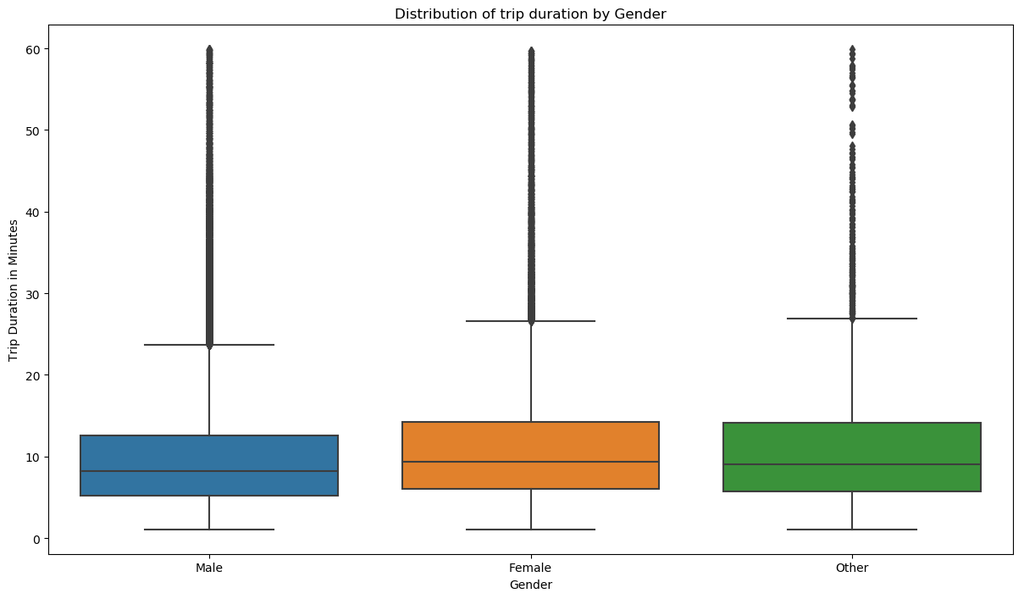

> Male riders have shorter trips compared to female riders and other gender types.

##### Distribution by user type

- What is the relationship between trip durations and user type?

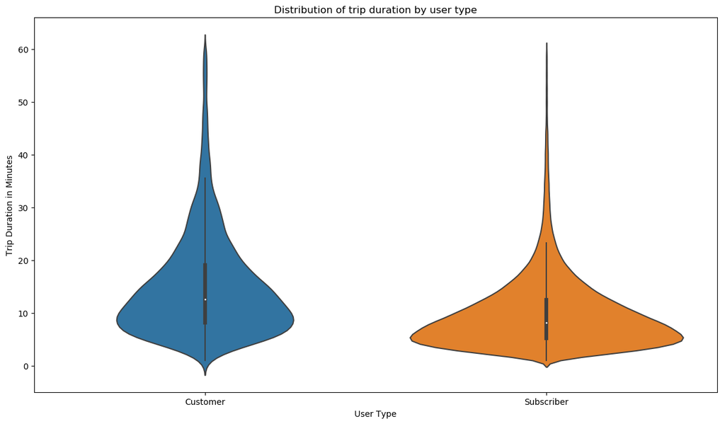

> From the above graph, customers have longer trips while subscribers have shorter trips.

##### Distribution by start time day of the week

- How do different days of the week affect the duration of the trips?

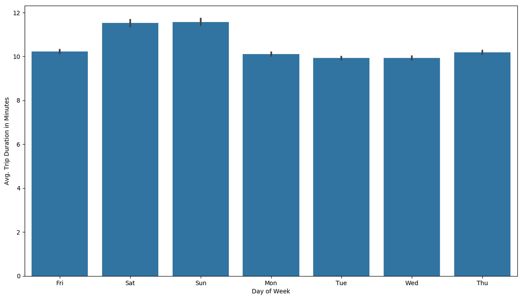

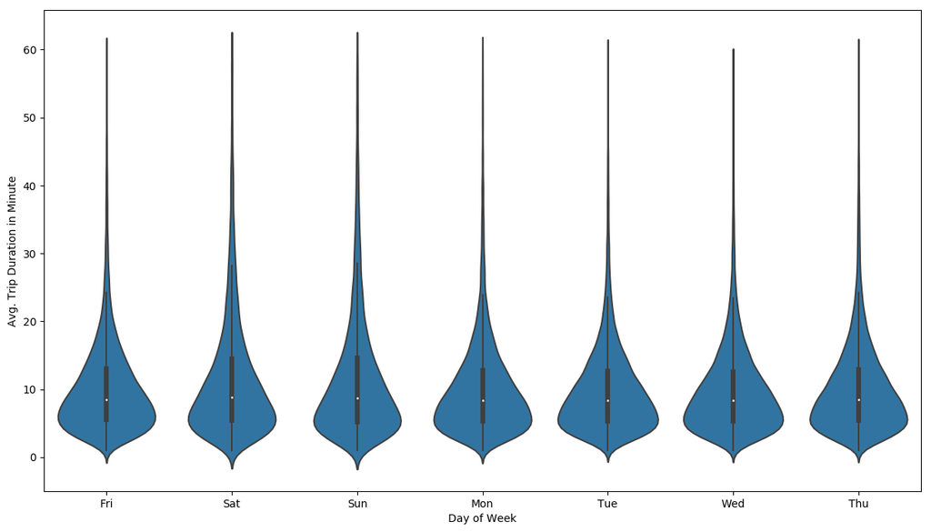

> Trips are longer during weekends (Saturdays and Sundays). One can say the trips are mostly taken for fun during weekends.